# plyr & ggplot2

author: Diogo Melo date: 2015/04/30 font-family: ‘Helvetica’ width: 1366 height: 768

# plyr

Plyr é um conjunto de funções que substituem a familia apply.

Queremos aplicar uma mesma função em subconjuntos

- Mais flexivel
- Fácil de paralelizar
- Com algumas facilidades importantes

https://github.com/diogro/plyr-ggplot2-Intro/blob/master/slides.md

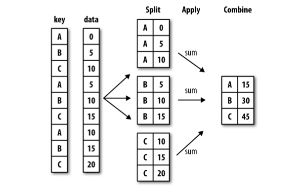

# Sintaxe geral

```r
__ply()
```

Primeira letra indica o tipo da entrada:

```r
a_ply(), d_ply(), l_ply()
```

Segunda letra indica o tipo da saída:

```r
_aply(), _dply(), _lply()
```

- (a)rray
- (l)ist
- (d)ata.frame

# l_ply

Listas tem divisão natural, então basta identificar o objeto de entrada e a função

```r
library(plyr)
simple_list <- list('zero' = rnorm(5),
                    'cinco' = rnorm(5, 5),
                    'dez' = rnorm(5, 10))
print(simple_list)
```

```
$zero
[1]  2.0332830 -0.9049479  0.6946419 -1.0612683 -0.6079308

$cinco
[1] 5.304322 5.200123 4.997118 5.399886 5.800771

$dez
[1] 8.533094 9.264648 9.751221 8.040753 8.433201
```

# l_ply

Listas tem divisão natural, então basta identificar o objeto de entrada e a função

```r
llply(simple_list, sum)
```

```
$zero
[1] 0.1537778

$cinco
[1] 26.70222

$dez
[1] 44.02292
```

```r
#identico a:
lapply(simple_list, sum)
```

# l_ply

Podemos também mudar o tipo da saida (diferente do lapply())

```r
laply(simple_list, mean)
```

```
[1] 0.03075556 5.34044398 8.80458353
```

```r
ldply(simple_list, quantile)
```

```
    .id        0%        25%        50%       75%     100%
1  zero -1.061268 -0.9049479 -0.6079308 0.6946419 2.033283
2 cinco  4.997118  5.2001233  5.3043216 5.3998856 5.800771
3   dez  8.040753  8.4332014  8.5330944 9.2646475 9.751221
```

# l_ply

Bom para conversões

```r
laply(simple_list, identity)
```

```
            1          2         3         4          5
[1,] 2.033283 -0.9049479 0.6946419 -1.061268 -0.6079308
[2,] 5.304322  5.2001233 4.9971184  5.399886  5.8007711
[3,] 8.533094  9.2646475 9.7512214  8.040753  8.4332014
```

```r
ldply(simple_list, identity)
```

```
    .id       V1         V2        V3        V4         V5
1  zero 2.033283 -0.9049479 0.6946419 -1.061268 -0.6079308
2 cinco 5.304322  5.2001233 4.9971184  5.399886  5.8007711
3   dez 8.533094  9.2646475 9.7512214  8.040753  8.4332014
```

# a_ply

Arrays não tem divisão natural, então um segundo argumento é necessario para indicar o sentido da operação sendo feita

```r
str(iris3)
```

```
 num [1:50, 1:4, 1:3] 5.1 4.9 4.7 4.6 5 5.4 4.6 5 4.4 4.9 ...
 - attr(*, "dimnames")=List of 3
  ..$ : NULL
  ..$ : chr [1:4] "Sepal L." "Sepal W." "Petal L." "Petal W."
  ..$ : chr [1:3] "Setosa" "Versicolor" "Virginica"
```

```r
aaply(iris3, 3, colMeans)
```

```
X1           Sepal L. Sepal W. Petal L. Petal W.
  Setosa        5.006    3.428    1.462    0.246
  Versicolor    5.936    2.770    4.260    1.326
  Virginica     6.588    2.974    5.552    2.026
```

Levemente diferente do apply.

```r
apply(iris3, 3, colMeans)
```

```
         Setosa Versicolor Virginica
Sepal L.  5.006      5.936     6.588
Sepal W.  3.428      2.770     2.974
Petal L.  1.462      4.260     5.552
Petal W.  0.246      1.326     2.026
```

# a_ply

```r
aaply(iris3, 3, colMeans)
```

```
X1           Sepal L. Sepal W. Petal L. Petal W.
  Setosa        5.006    3.428    1.462    0.246
  Versicolor    5.936    2.770    4.260    1.326
  Virginica     6.588    2.974    5.552    2.026
```

Ou…

```r
aaply(iris3, c(2, 3), mean)
```

```
          X2
X1         Setosa Versicolor Virginica
  Sepal L.  5.006      5.936     6.588
  Sepal W.  3.428      2.770     2.974
  Petal L.  1.462      4.260     5.552
  Petal W.  0.246      1.326     2.026
```

# a_ply

Novamente podemos mudar a saída

- data.frame:

```r
adply(iris3, 3, colMeans, .id = 'Species')
```

```
     Species Sepal L. Sepal W. Petal L. Petal W.
1     Setosa    5.006    3.428    1.462    0.246
2 Versicolor    5.936    2.770    4.260    1.326
3  Virginica    6.588    2.974    5.552    2.026
```

# a_ply

Novamente podemos mudar a saída

- list:

```r
alply(iris3, 3, colMeans, .dims = TRUE)
```

```
$Setosa
Sepal L. Sepal W. Petal L. Petal W.
   5.006    3.428    1.462    0.246

$Versicolor
Sepal L. Sepal W. Petal L. Petal W.
   5.936    2.770    4.260    1.326

$Virginica
Sepal L. Sepal W. Petal L. Petal W.
   6.588    2.974    5.552    2.026

attr(,"split_type")
[1] "array"
attr(,"split_labels")
          X1
1     Setosa
2 Versicolor
3  Virginica
```

# a_ply

O a_ply() tb é útil para converter arrays:

- data.frames

```r
iris_df = adply(iris3, 3, .id = 'Species')
head(iris_df)
```

```
  Species Sepal L. Sepal W. Petal L. Petal W.
1  Setosa      5.1      3.5      1.4      0.2
2  Setosa      4.9      3.0      1.4      0.2
3  Setosa      4.7      3.2      1.3      0.2
4  Setosa      4.6      3.1      1.5      0.2
5  Setosa      5.0      3.6      1.4      0.2
6  Setosa      5.4      3.9      1.7      0.4
```

# a_ply

O a_ply() tb é útil para converter arrays:

- listas

```r
iris_list = alply(iris3, 3, .dims = TRUE)
names(iris_list)
```

```
[1] "Setosa"     "Versicolor" "Virginica"
```

```r
class(iris_list[[1]])
```

```
[1] "matrix"
```

```r
str(iris_list[[1]])
```

```
 num [1:50, 1:4] 5.1 4.9 4.7 4.6 5 5.4 4.6 5 4.4 4.9 ...
 - attr(*, "dimnames")=List of 2
  ..$ : NULL
  ..$ : chr [1:4] "Sepal L." "Sepal W." "Petal L." "Petal W."
```

# d_ply

d_ply é a função mais complexa

- seu uso geralmente envolve o uso de funções auxiliares;
- muita da funcionalidade básica é mais simples no dplyr;
- ainda é útil para operações complicadas, que operam em mais de uma linha simultaneamente.
- básicamente um aggregate-on-steroids

# d_ply

```r
library(gapminder)
str(gapminder)
```

```
'data.frame':   1704 obs. of  6 variables:
 $ country  : Factor w/ 142 levels "Afghanistan",..: 1 1 1 1 1 1 1 1 1 1 ...
 $ continent: Factor w/ 5 levels "Africa","Americas",..: 3 3 3 3 3 3 3 3 3 3 ...
 $ year     : num  1952 1957 1962 1967 1972 ...
 $ lifeExp  : num  28.8 30.3 32 34 36.1 ...
 $ pop      : num  8425333 9240934 10267083 11537966 13079460 ...
 $ gdpPercap: num  779 821 853 836 740 ...
```

# d_ply

O segundo argumento é um coluna do data.frame que será usada para subdividi-lo

```r
dlply(gapminder, 'country')[[1]]
```

```
       country continent year lifeExp      pop gdpPercap
1  Afghanistan      Asia 1952  28.801  8425333  779.4453
2  Afghanistan      Asia 1957  30.332  9240934  820.8530
3  Afghanistan      Asia 1962  31.997 10267083  853.1007
4  Afghanistan      Asia 1967  34.020 11537966  836.1971
5  Afghanistan      Asia 1972  36.088 13079460  739.9811
6  Afghanistan      Asia 1977  38.438 14880372  786.1134
7  Afghanistan      Asia 1982  39.854 12881816  978.0114
8  Afghanistan      Asia 1987  40.822 13867957  852.3959
9  Afghanistan      Asia 1992  41.674 16317921  649.3414
10 Afghanistan      Asia 1997  41.763 22227415  635.3414
11 Afghanistan      Asia 2002  42.129 25268405  726.7341
12 Afghanistan      Asia 2007  43.828 31889923  974.5803
```

# d_ply - Principal ponto de discórdia:

- O data.frame é subdividido de acordo com uma (ou mais) coluna(s) de indicadores, mas os “sub”-data.frames ainda contém essas colunas!

```r
dlply(gapminder, 'country')[[1]]
```

```
       country continent year lifeExp      pop gdpPercap
1  Afghanistan      Asia 1952  28.801  8425333  779.4453
2  Afghanistan      Asia 1957  30.332  9240934  820.8530
3  Afghanistan      Asia 1962  31.997 10267083  853.1007
4  Afghanistan      Asia 1967  34.020 11537966  836.1971
5  Afghanistan      Asia 1972  36.088 13079460  739.9811
6  Afghanistan      Asia 1977  38.438 14880372  786.1134
7  Afghanistan      Asia 1982  39.854 12881816  978.0114
8  Afghanistan      Asia 1987  40.822 13867957  852.3959
9  Afghanistan      Asia 1992  41.674 16317921  649.3414
10 Afghanistan      Asia 1997  41.763 22227415  635.3414
11 Afghanistan      Asia 2002  42.129 25268405  726.7341
12 Afghanistan      Asia 2007  43.828 31889923  974.5803
```

# d_ply

Isso é um problema quando queremos fazer operações nas colunas numéricas apenas:

```r
head(ddply(gapminder, 'country', mean))
```

```
      country V1
1 Afghanistan NA
2     Albania NA
3     Algeria NA
4      Angola NA
5   Argentina NA
6   Australia NA
```

# d_ply

Isso é um problema quando queremos fazer operações nas colunas numéricas apenas:

```r
head(ddply(gapminder, 'country', mean))
```

A função numcolwise() resolve esse problema, mas ela é aplicada na função!!

```r
head(ddply(gapminder, 'country', numcolwise(mean)))
```

```
      country   year  lifeExp      pop  gdpPercap
1 Afghanistan 1979.5 37.47883 15823715   802.6746
2     Albania 1979.5 68.43292  2580249  3255.3666
3     Algeria 1979.5 59.03017 19875406  4426.0260
4      Angola 1979.5 37.88350  7309390  3607.1005
5   Argentina 1979.5 69.06042 28602240  8955.5538
6   Australia 1979.5 74.66292 14649312 19980.5956
```

# d_ply

A função .() permite omitir as aspas e fazer operações nas colunas:

```r
head(ddply(gapminder, .(continent, log(year)), numcolwise(mean)), 12)
```

```
   continent log(year)  lifeExp      pop gdpPercap
1     Africa  7.576610 39.13550  4570010  1252.572
2     Africa  7.579168 41.26635  5093033  1385.236
3     Africa  7.581720 43.31944  5702247  1598.079
4     Africa  7.584265 45.33454  6447875  2050.364
5     Africa  7.586804 47.45094  7305376  2339.616
6     Africa  7.589336 49.58042  8328097  2585.939
7     Africa  7.591862 51.59287  9602857  2481.593
8     Africa  7.594381 53.34479 11054502  2282.669
9     Africa  7.596894 53.62958 12674645  2281.810
10    Africa  7.599401 53.59827 14304480  2378.760
11    Africa  7.601902 53.32523 16033152  2599.385
12    Africa  7.604396 54.80604 17875763  3089.033
```

# d_ply

Podemos também usar formulas:

```r
head(ddply(gapminder, ~ continent + year, numcolwise(mean)), 12)
```

```
   continent year  lifeExp      pop gdpPercap
1     Africa 1952 39.13550  4570010  1252.572
2     Africa 1957 41.26635  5093033  1385.236
3     Africa 1962 43.31944  5702247  1598.079
4     Africa 1967 45.33454  6447875  2050.364
5     Africa 1972 47.45094  7305376  2339.616
6     Africa 1977 49.58042  8328097  2585.939
7     Africa 1982 51.59287  9602857  2481.593
8     Africa 1987 53.34479 11054502  2282.669
9     Africa 1992 53.62958 12674645  2281.810
10    Africa 1997 53.59827 14304480  2378.760
11    Africa 2002 53.32523 16033152  2599.385
12    Africa 2007 54.80604 17875763  3089.033
```

# d_ply

- Se quisermos operar sobre mais de uma coluna numérica simultaneamente, o numcolwise não serve
- Nesse caso, o melhor é usar uma função que faça a indexação desejada:

```r
l_iris <- dlply(iris, ~ Species, '[', 1:3)
llply(l_iris, cor)[[1]]
```

```
             Sepal.Length Sepal.Width Petal.Length
Sepal.Length    1.0000000   0.7425467    0.2671758
Sepal.Width     0.7425467   1.0000000    0.1777000
Petal.Length    0.2671758   0.1777000    1.0000000
```

# d_ply

Ou, usando o pipe (%>%) do pacote magrittr

```r
library(magrittr)
dlply(iris, ~ Species, '[', 1:3) %>% llply(., cor)
```

```
$setosa
             Sepal.Length Sepal.Width Petal.Length
Sepal.Length    1.0000000   0.7425467    0.2671758
Sepal.Width     0.7425467   1.0000000    0.1777000
Petal.Length    0.2671758   0.1777000    1.0000000

$versicolor
             Sepal.Length Sepal.Width Petal.Length
Sepal.Length    1.0000000   0.5259107    0.7540490
Sepal.Width     0.5259107   1.0000000    0.5605221
Petal.Length    0.7540490   0.5605221    1.0000000

$virginica
             Sepal.Length Sepal.Width Petal.Length
Sepal.Length    1.0000000   0.4572278    0.8642247
Sepal.Width     0.4572278   1.0000000    0.4010446
Petal.Length    0.8642247   0.4010446    1.0000000
```

# plyr + magrittr + evolqg

```r
library(evolqg)
data(dentus)
dlply(dentus, ~ species, '[', 1:4) %>%
  llply(cov) %>%
  ldply(MeanMatrixStatistics, .id = 'Species')
```

```
  Species MeanSquaredCorrelation      pc1%       ICV respondability
1       A             0.26304221 0.5942705 1.0301592      1.2208715
2       B             0.12459035 0.4659021 0.7065384      1.1283414
3       C             0.15157218 0.4865811 0.7509757      1.1356968
4       D             0.42069839 0.7331679 1.2971322      1.3638349
5       E             0.04036267 0.4049835 0.4711963      0.9328489
  evolvability conditional.evolvability  autonomy flexibility constraints
1    0.9872532                0.4915986 0.5185775   0.7776295   0.7318177
2    1.0059573                0.7344412 0.7287692   0.8800182   0.6603558
3    0.9970017                0.6584752 0.6499890   0.8614851   0.6719413
4    1.0253554                0.4763524 0.5351399   0.7341142   0.8597069
5    0.8848132                0.7871785 0.8900755   0.9469164   0.6137210
```

# ggplot2

left: 35%

“ggplot2 is a plotting system for R, based on the grammar of graphics, which tries to take the good parts of base and lattice graphics and none of the bad parts. It takes care of many of the fiddly details that make plotting a hassle (like drawing legends) as well as providing a powerful model of graphics that makes it easy to produce complex multi-layered graphics.”

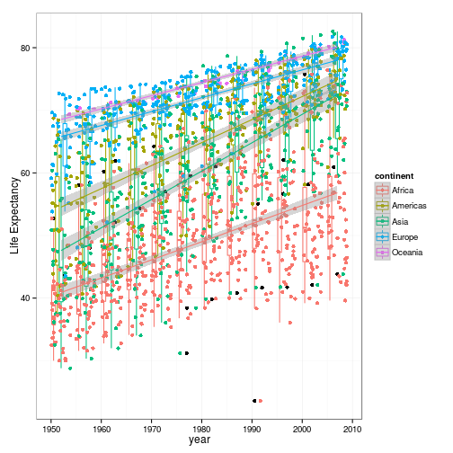

# ggplot

Todas os plots no ggplot tem a mesma estrutura e dependem bastante do objeto de entrada:

- SEMPRE um data.frame;
- Cada linha é uma observação;
- Geralmente é melhor usar data.frames no formato “narrow”;
- Cores, grupos, separações em paineis são todas definidas por fatores (yay!!)

# ggplot

Regra geral:

```r
ggplot(data_frame_entrada, aes(x = coluna_eixo_x,
                               y = coluna_eixo_y,
                               group = coluna_agrupadora,
                               color = coluna_das_cores))
+ geom_tipo_do_grafico(opcoes que não dependem dos dados,
                       aes(opcoes que dependem))
```

# ggplot - mudando cores

```r
ggplot(gapminder, aes(x = log(gdpPercap),
                      y = log(lifeExp),
                      group = country,
                      color = year)) + geom_point()
```

```r
ggplot(gapminder, aes(x = log(gdpPercap),
                      y = log(lifeExp),
                      group = country,
                      color = continent)) + geom_point()
```

# ggplot - mudando cores

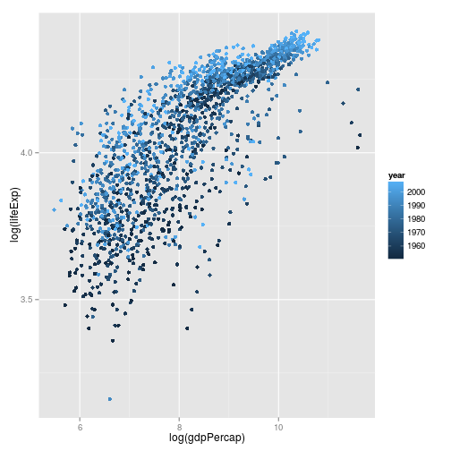

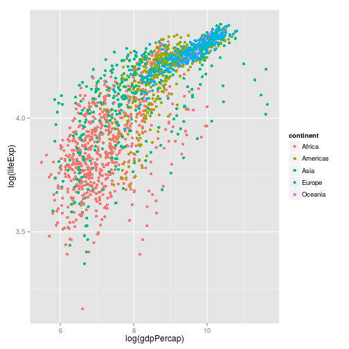

# ggplot - objetos graficos

- No ggplot os objetos gráficos podem ser manipulados ou armazenados, diferente dos plots padrão onde os gráficos são “efeitos colaterais”
- Isso significa que vc pode alterar gráficos já feitos usando “+”

```r
meu_grafico = ggplot(gapminder, aes(x = log(gdpPercap),
                      y = log(lifeExp))) + geom_point(aes(color = continent))
```

# ggplot - objetos graficos

left: 60%

Algumas opções comuns:

```r
meu_grafico = meu_grafico +
    labs(x = "GDP per capta",
         y = "Expectativa de vida")

meu_grafico = meu_grafico +
  theme(text = element_text(size = 30),
    legend.title =
        element_text(face = "italic")) +
  scale_color_discrete(name = "Continente")
```

```r
meu_grafico
```

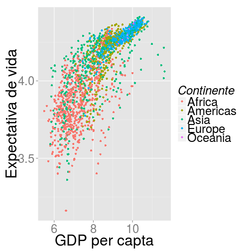

# ggplot - temas

left: 30%

Temas prontos!

```r
meu_grafico = meu_grafico + theme_bw()
```

```r
meu_grafico
```

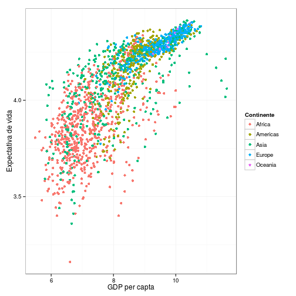

# ggplot - temas

Temas prontos!

```r
library(ggthemes)
meu_grafico = ggplot(gapminder,
 aes(x = log(gdpPercap),
     y = log(lifeExp))) +
  geom_point(size = 3,
  aes(shape = continent)) +
  theme_wsj()
```

```r
meu_grafico
```

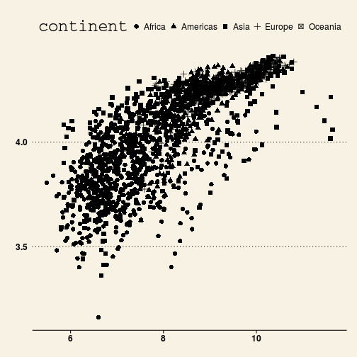

# ggplot - outros tipos de gráficos

- regressão linear

```r
meu_grafico = ggplot(gapminder,  aes(x = log(gdpPercap), y = log(lifeExp))) + geom_point(aes(color = continent))
```

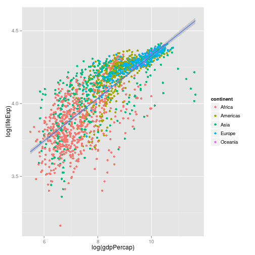

```r
meu_grafico + geom_smooth(method = "lm")
```

# ggplot - outros tipos de gráficos

- regressão linear por continente

```r
meu_grafico = ggplot(gapminder,  aes(x = log(gdpPercap), y = log(lifeExp))) + geom_point(aes(color = continent))
```

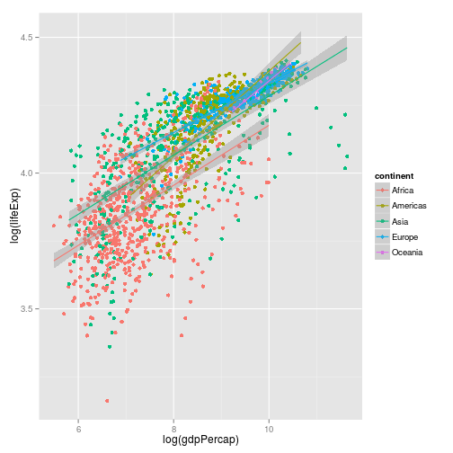

```r
meu_grafico + geom_smooth(method = "lm", aes(color = continent))
```

# ggplot - outros tipos de gráficos

- boxplot

```r
meu_grafico = ggplot(gapminder,
  aes(year, lifeExp,
  group = interaction(year,
                continent),
  color = continent))
```

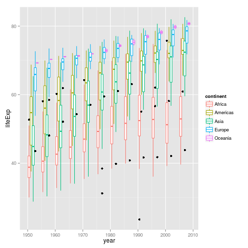

```r
meu_grafico + geom_boxplot()
```

# ggplot - combinando tipos de gráficos

- boxplot

```r
meu_grafico = ggplot(gapminder,
  aes(year, lifeExp,
  group = interaction(year,
                continent),
  color = continent))
```

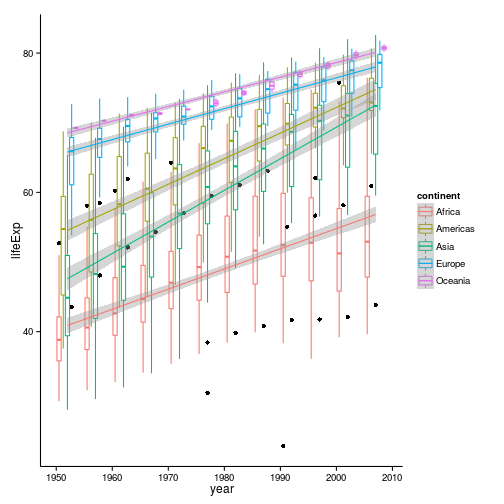

```r
meu_grafico + geom_boxplot() + geom_smooth(method = "lm", aes(group = continent)) + theme_classic()
```

# ggplot - outros tipos de gráficos

```r
geom_histogram()
geom_jitter()
geom_text(aes(label = coluna_texto))
geom_violin()
geom_errorbar(aes(ymax, ymin))
...
```

# ggplot - outros tipos de gráficos

Documentação

- http://docs.ggplot2.org/current/
- How to format plots for publication using ggplot2 - http://www.noamross.net/blog/2013/11/20/formatting-plots-for-pubs.html
- http://stackoverflow.com/